# PSU Foot Traffic Analysis

An study on visitation trends at PSU’s Downtown Portland Campus

Author

ECOnorthwest

Published

January 15, 2026

Portland State University’s urban campus serves as a cultural, economic and educational activity center in the heart of Portland. The University is a significant employer in the Central City and employs over 5,000 staff (as of Fall 2024).[^1] Students travelling to campus are often joined by community members looking to enjoy performances at Lincoln Hall, watch sports at the Viking Pavilion, or stock up on produce and other goodies at the Portland Farmers Market. Conferences hosted on campus attract visitors from far and wide. Students residing in dormitories and other student housing near campus also help contribute to a vibrant neighborhood.

The COVID-19 pandemic brought about a seismic shift in education and employment dynamics across the country. Online instruction helped expand educational opportunities to a wider range of students, while hybrid work models enabled employees to have greater flexibility. These same dynamics played out at PSU. Roughly 60 percent of undergraduate students participated in some form of distance (online) education as of Fall 2024, compared to 43 percent in Fall 2018.[^2]

In late 2025, PSU announced a return-to-office mandate for University employees, requiring four days in the office, with in-office days decided by each employee. Meanwhile across the nation, such shifts in employment and pandemic recovery efforts have resulted in implications for street activity in commercial corridors, especially city centers. PSU has contracted with ECOnorthwest to track foot traffic trends for the campus and key hotspots to better understand these evolving visitation patterns and activity. ECO’s quarterly foot traffic data pulls will help to answer two questions:

- How has PSU’s four day return to campus policy affected foot traffic?
- Where on campus is the recovery most prominent?

**NoteA Note on the Data**

To estimate visitation patterns on the PSU campus, ECOnorthwest uses information extrapolated by the analytics company Placer AI. Placer relies on location data from location-based services on devices such as cellphones (for users who have enabled location sharing). This data is then anonymised and aggregated using proprietary algorithms to provide insights on visitation patterns. We used Placer.ai’s proprietary private services in the absence of consistent and reliable publicly available user data.

- **Visits to the campus neighborhood should not be interpreted as visits to the University itself.** Although this analysis is designed to track PSU’s return-to-office policy, visitors may visit the PSU campus neighborhood for a variety of reasons, such as employees, or visitors of other establishments based in the neighborhood. Therefore, in order to avoid potential misclassifications caused by the conflation of irregular hybrid schedules and visitor trends, we aggregate employees and out-of-market visitors together.
- **Classification of visitors is based on visitation patterns, not known relations to the campus.** Placer categorizes the place of residence based on the location where the device consistently spends night hours, and the place of employment as where the device consistently spends traditional work hours.
- **This analysis utilizes quarterly averages when reporting visit trends.** This approach allows us to smooth out daily or weekly anomalies and provides a clear view of incremental change in foot traffic year over year.
- **Some changes in visitation trends may be due to changing data extrapolation algorithms.** Placer applies its proprietary algorithms to the location data to generate visitation trends. These algorithms are subject to change and it is possible that some perceived trends are a result of this statistical process rather than actual, on-the-ground visitation.

## Campus Neighborhood Visitation

Overall weekday visitation to the PSU campus neighborhood has recovered 94% since Fall 2019. The campus neighborhood (seen in Figure 1) is a 108-acre area and captures visitation dynamics driven by PSU as well as other employers, destinations and landmarks in the area. This neighborhood analysis helps provide a more comprehensive picture of activation in the area. In this analysis, people who live in this neighborhood are classified as Residents. Anyone who resides outside the neighborhood but visits and spends more than 45 minutes in the campus neighborhood on a given day is counted as a Visitor or Employee.

Figure 1: Campus Neighborhood Map

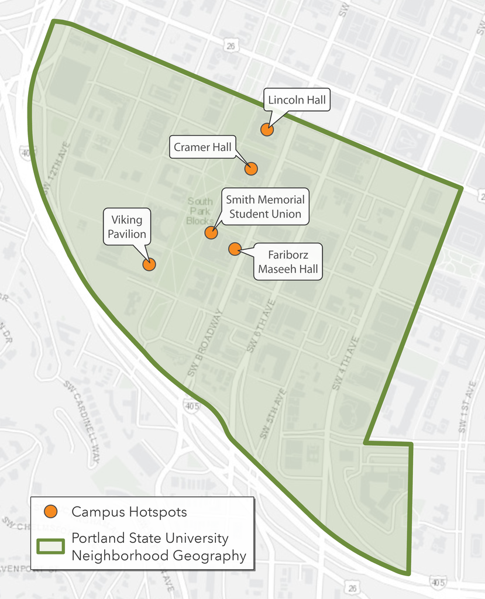

## How has PSU’s four day return to campus policy affected foot traffic?

The total number of residents living in this area are roughly in line with Fall 2019 levels. Neighborhood activation trends have thus far been driven by visitors such as employees, students, event attendees and tourists. In Q4 2025, the area saw approximately 10,446 visits over the average weekday. This is about 6% lower than Q4 2019 and 5% higher of visits relative to Q4 2024.

Figure 2: Average Weekday Visits indexed to Fall 2019

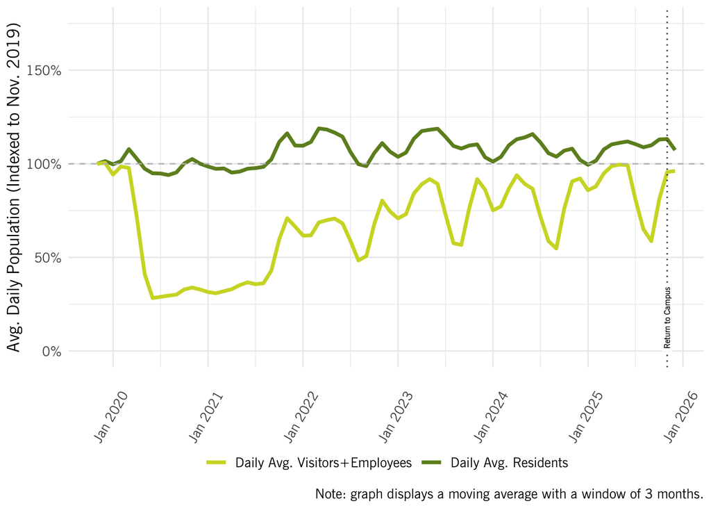

When limiting the analysis to weekends in Q4 2025, the average visitation was 6,276. This is about 8% higher than Q4 2019 and 3% higher of visits relative to Q4 2024.

Figure 3: Average Weekend Visits indexed to Fall 2019

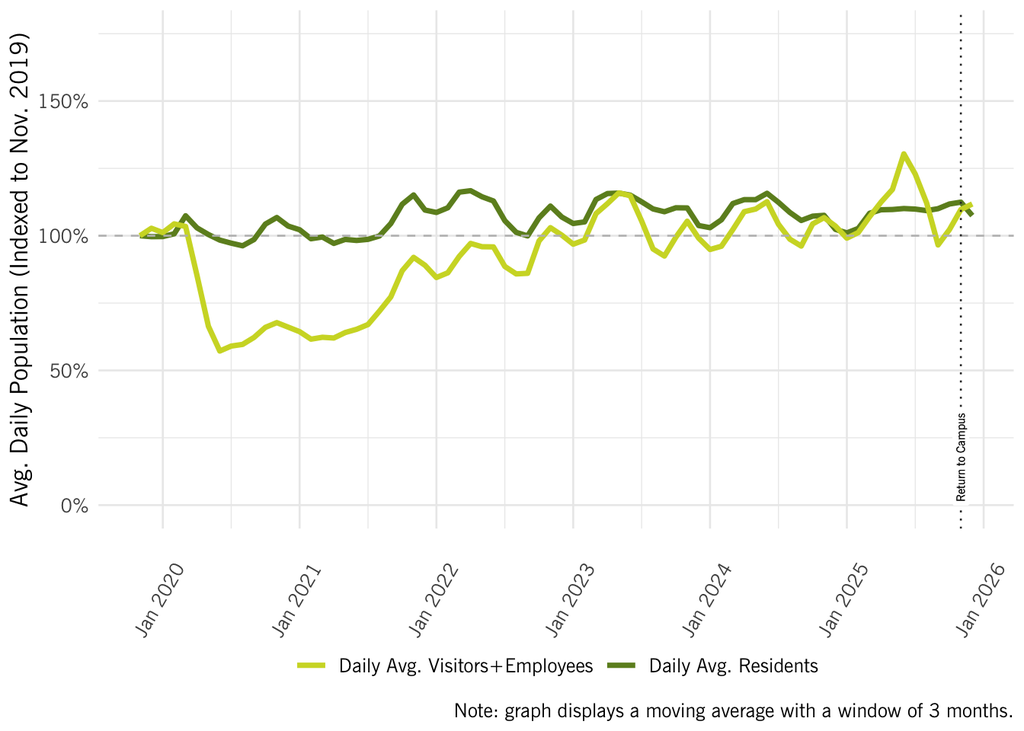

**Tip**Why we separate weekday and weekend trends?**

We treat these time frames separately to capture two distinct trends of campus recovery. The weekday analysis focuses on the impact of the “return-to-campus” mandate for employees and students. In contrast, the weekend analysis highlights the district’s role as a cultural destination, capturing event-driven traffic from major draws such as the Portland Farmers Market or events at the Viking Pavilion and Lincoln Hall.

### What days do visitors visit the campus neighborhood?

Unsurprisingly, non-resident visitor volume is higher over the week compared to the weekend. The average Monday in Q4 2025 saw a 9% increase in non-resident visitation compared to the average Monday in Q4 2024. The graph below shows visitation trends by day of the week for the two periods.

Figure 4: Side-by-side comparison of Q4 2025 to Q4 2024

(a) Q4 2025

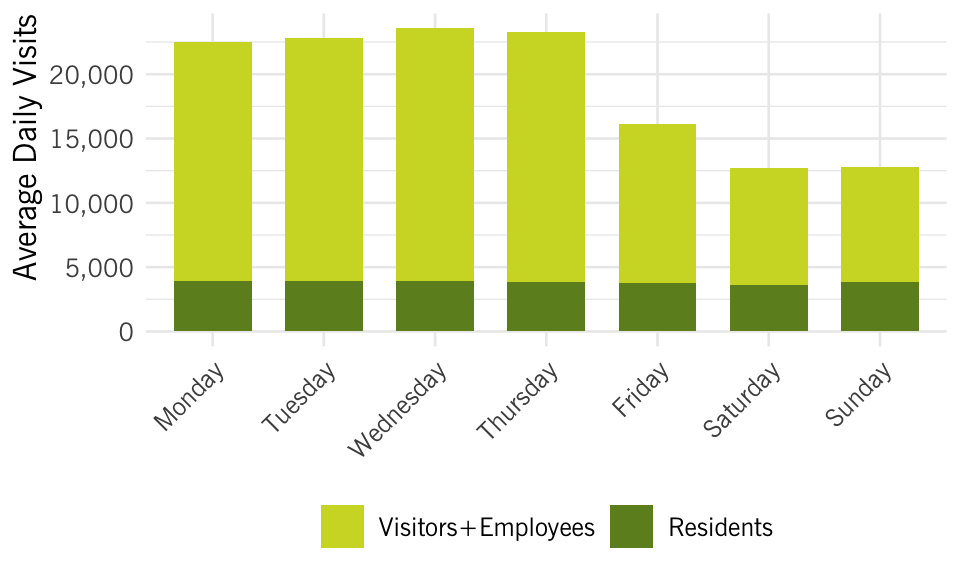

(b) Q4 2024

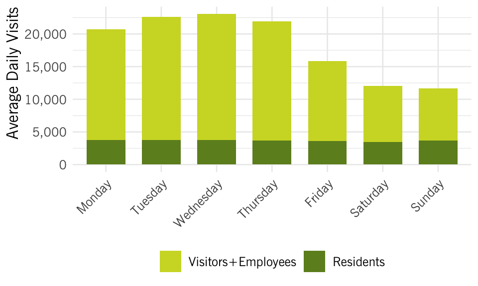

### What time during the day do visitors visit the campus neighborhood?

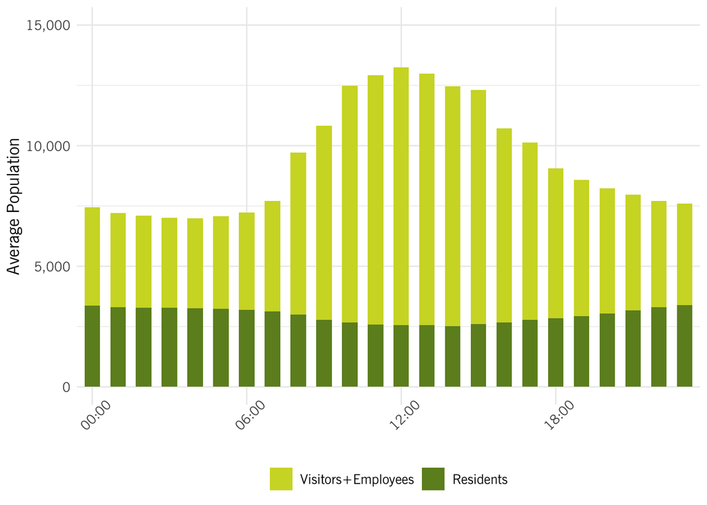

Unlike weekdays, weekend activation is sustained evenly throughout the day, with no significant drop-off in the late night or early morning hours. However, like weekdays, changes from Q4 2024 to Q4 2025 are again marginal. This steady baseline of activity persists in both years, though 2025 data indicates a slight activation boost from 2024 in the early afternoon, registering a 10% increase in visits during that window compared to the previous year.

Figure 6: Weekend hourly foot traffic, Q4 2025

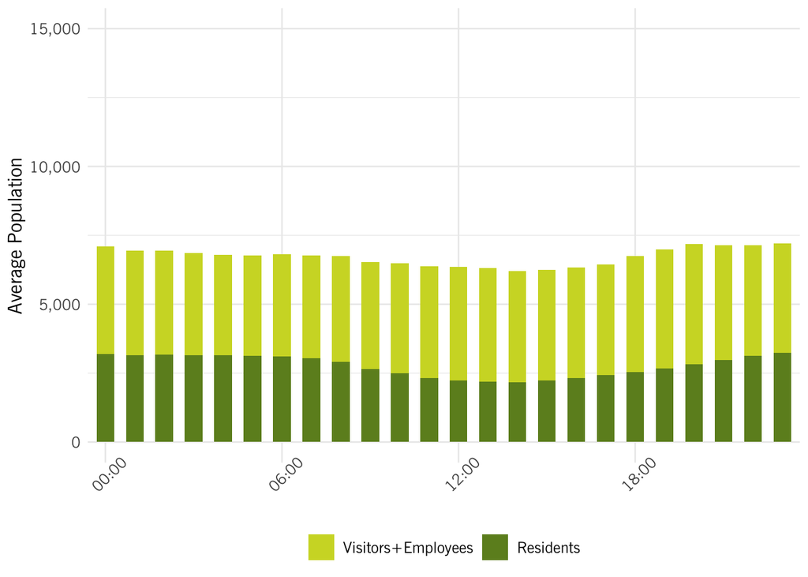

## Where on campus is the recovery most prominent?

In addition to the campus neighborhood as a whole, we also analyze visitation to specific campus buildings.

### Viking Pavilion

The average visits per day to Viking Pavilion went from 10,266 in Q4 2024 to 11,915 in Q4 2025, a 16% increase. 18% of visits to Viking Pavilion happened on a Monday. Over the week, the majority of visits happened in the hours of 11:00 a.m. to 9:00 p.m.

Average Daily Foot Traffic 2025 Q4

11,915

Change from 2024 Q4

+16%

Busiest Day

Monday, 18% of weekly volume

### Lincoln Hall

The average visits per day to Lincoln Hall went from 20,435 in Q4 2024 to 23,527 in Q4 2025, a 15% increase. 23% of visits to Lincoln Hall happened on a Wednesday. Over the week, the majority of visits happened in the hours of 9:00 a.m. to 7:00 p.m.

Average Daily Foot Traffic 2025 Q4

23,527

Change from 2024 Q4

+15%

Busiest Day

Wednesday, 23% of weekly volume

### Smith Memorial

The average visits per day to Smith Memorial went from 19,662 in Q4 2024 to 19,461 in Q4 2025, a 1% decrease. 25% of visits to Smith Memorial happened on a Wednesday. Over the week, the majority of visits happened in the hours of 11:00 a.m. to 3:00 p.m.

Average Daily Foot Traffic 2025 Q4

19,461

Change from 2024 Q4

-1%

Busiest Day

Wednesday, 25% of weekly volume

### Cramer Hall and FMH

The average visits per day to Cramer Hall and FMH went from 46,097 in Q4 2024 to 48,101 in Q4 2025, a 4% increase. 26% of visits to Cramer Hall and FMH happened on a Wednesday. Over the week, the majority of visits happened in the hours of 9:00 a.m. to 4:00 p.m.

Average Daily Foot Traffic 2025 Q4

48,101

Change from 2024 Q4

+4%

Busiest Day

Wednesday, 26% of weekly volume

## Footnotes

[^1]: www.pdx.edu/portland-state-university-facts.
[^2]: nces.ed.gov/ipeds/institution-profile/209807#enrollment